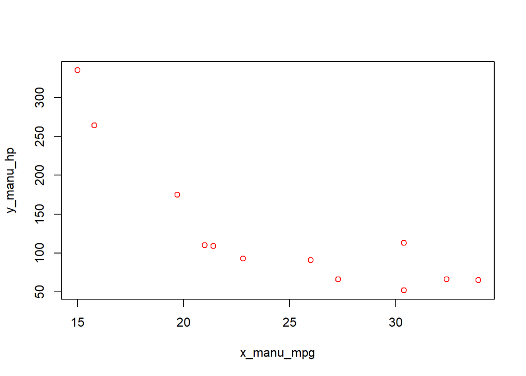

```r
x_manu_mpg <- manual$mpg
y_manu_hp <- manual$hp
plot(x_manu_mpg, y_manu_hp, col = 'red')#somewhat negative relationship
```

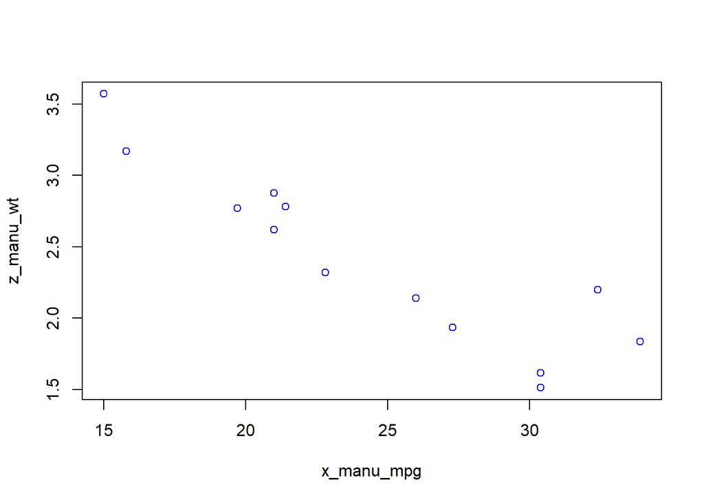

```r
z_manu_wt <- manual$wt
plot(x_manu_mpg, z_manu_wt, col = 'blue')# good negative relationship
```

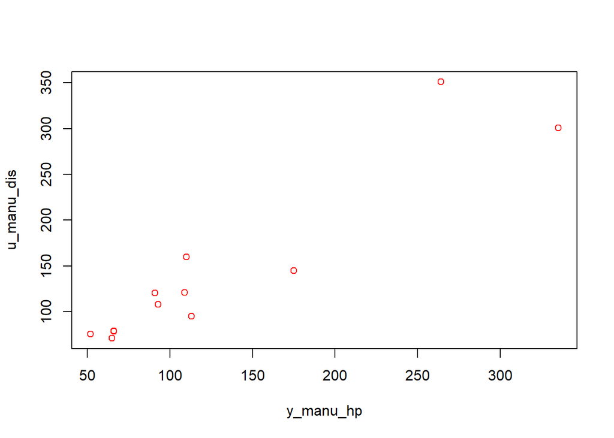

```r
u_manu_dis <- manual$disp
plot(y_manu_hp, u_manu_dis, col = 'red')
```

Correlation function

```r
s_xx <- function(x){
  sum(x*x) - ((sum(x))^2) / length(x)
}

s_xy <-function(x,y){
  sum(x*y) - (sum(x)*sum(y))/length(x)
}
s_yy <- function(y){
  sum(y*y) - ((sum(y))^2) / length(y)
}

corr <- function(x,y){
  s_xy(x,y)/ (sqrt(s_xx(x))*sqrt(s_xx(y)))
}
corr_manual <- corr(x_manu_mpg, z_manu_wt)
corr_manual
```

```
## [1] -0.9089148
```

```r
corr_horpwr_disp <- corr(y_manu_hp, u_manu_dis)
corr_horpwr_disp # since corr_horpwr_disp is 0.9240353 thus there is strong relationship
```

```
## [1] 0.9240353
```

3.2 Choose two pairs of your choice that suggest strong linear relationship, for each of these pairs identify what the explanatory and response variables will be.

Either using the `lm’ function or the functions, estimate the model parameters for the simple linear regression for both of these pairs.

```r
linearModel_mpg_hp <- lm(mpg~hp, mtcars)
linearModel_mpg_hp
```

```
##
## Call:
## lm(formula = mpg ~ hp, data = mtcars)
##
## Coefficients:
## (Intercept)           hp
##    30.09886     -0.06823
```

```r
linearModel_horpwr_disp <- lm(hp~disp, mtcars)
```

3.3 interpret the slope parameter estimates that you have computed appropriately. b_0 = 30.09886 and b_1 = -0.06823

```r
linearModel_mpg_hp
```

```
##
## Call:
## lm(formula = mpg ~ hp, data = mtcars)
##
## Coefficients:
## (Intercept)           hp
##    30.09886     -0.06823
```

```r
linearModel_horpwr_disp
```

```
##
## Call:
## lm(formula = hp ~ disp, data = mtcars)
##
## Coefficients:
## (Intercept)         disp
##     45.7345       0.4376
```

b_0 45.7345 and b_1 0.4376